# Visualizing phylogenies

Author

Jeet Sukumaran

**Proficiencies**

- create a phylogeny plot with `plot`;
- distinguish topology-only and edge-length-scaled layouts;
- display leaf, node, and edge information;
- draw a phylogeny into an existing Makie `Axis` with `plot!`; and
- use the plotted node coordinates to add another Makie graphic.

**Related**

- Creating Makie figures
- The phylogeny representations tutorial explains how to parse strings and read files.
- The Newick primer describes the format’s punctuation and grammar.

## 1 Setting up the environment

**NoteRequired packages**

`GLMakie` and `PhyloMakie.jl` need to be installed in the active environment. If this has not already been done, run:

```julia
using Pkg

Pkg.add("GLMakie")
Pkg.add("PhyloMakie")
```

We load the PhyloMakie library into the active environment using:

```julia
using PhyloMakie
```

We also load the “Makie backend” rendering engine:

```julia
using GLMakie
```

## 2 Generating the phylogeny

The `newick` string macro converts a phylogeny represented as a Julia string (that is, a value of the Julia type, `Base.String`) in Newick format to a representation that PhyloMakie knows how to work with (a value of the type `PhyloMakie.LineageNetwork`):

```julia
phylogeny = newick"((A:1,B:4)AB:8,(C:2,D:6)CD:2)R:2;"
```

```
LineageNetwork(7 nodes, 6 edges, 4 leaves, 0 hybrid nodes, rooted)
```

- The construct `"((A:1,B:4)AB:8,(C:2,D:6)CD:2)R:2;"` is evaluated by Julia as a `Base.String` literal value.
- The `newick` macro provided by PhyloMakie calls `PhyloMakie.parsephylogeny` to create and return a value of `LineageNetwork` type corresponding to the string value passed to it as its input argument.

## 3 Plotting the phylogeny

`plot(phylogeny)` creates a new figure (a value of type `Makie.Figure`), a new axis (`Makie.Axis`), and then plots the given phylogeny onto the new axis. It returns these objects in a `FigureAxisPlot` value.

```julia
plot_result = plot(phylogeny)
```

This value has the properties `figure`, `axis`, and `plot`, which hold the new `Figure`, `Axis`, and `PhyloMakie.PhylogenyPlot` values, respectively:

```julia
propertynames(plot_result)
```

```
(:figure, :axis, :plot)
```

- `plot_result.figure` is a [Makie `Figure`](https://docs.makie.org/stable/explanations/figure.html), used to display or save as-is, or for additional composition with Makie.
- `plot_result.axis` is a [Makie `Axis`](https://docs.makie.org/stable/explanations/axis.html), used as a destination if we want to plot additional elements to the same drawing region and coordinate reference system as the phylogeny.
- `plot_result.plot` is a `PhyloMakie.PhylogenyPlot`, which holds the points, lines, text, and other marks that visualize the phylogeny. We use this value to update plot attributes or retrieve information such as node coordinates.

For example, to display the figure, just ask the REPL to evaluate its value:

```julia
plot_result.figure
```

[output not shown]

while to save it to a file we would pass the figure to `save`:

```
save("phylogeny.png", plot_result.figure)
```

## 4 Setting plot attributes

Plot attributes control various aspects of the rendered phylogeny.

For example, the default `useedgelength = false` draws the topology without scaling edges by their stored lengths. We set `useedgelength = true` to make each edge extension proportional to its phylogeny edge length:

```julia
plot(phylogeny, useedgelength = true)
```

[output not shown]

The full interface of the plotting function can be seen by inspecting the documentation of the plotting function provided by PhyloMakie:

**Tip`julia> @doc PhyloMakie.phylogenyplot`**

```julia
@doc PhyloMakie.phylogenyplot
```

````
```
  phylogenyplot(phylogeny; kwargs...) -> Makie.FigureAxisPlot
  phylogenyplot!(axis, phylogeny; kwargs...) -> PhylogenyPlot

  Plot any AbstractPhylogeny implementing the Phylogenies accessor interface
  with the PhyloMakie Makie recipe.

  Use plot(phylogeny; kwargs...) and plot!(axis, phylogeny; kwargs...) for the
  standard Makie API. phylogenyplot and phylogenyplot! are package-specific
  aliases generated by the recipe. Supported attributes control layout style,
  edge lengths, leaf labels, node labels, edge labels, colors, widths,
  hybrid-edge arrows, and data limits. Use nodeimages and edgeimages to attach
  image annotations without depending on implementation-assigned node or edge
  indices.

  Plot type
  =========

  The plot type alias for the phylogenyplot function is PhylogenyPlot.

  Attributes
  ==========

  arrowlen = nothing — Set the minor hybrid edge arrow length.

  clip_planes = @inherit clip_planes Makie.automatic — Inherited Makie clip
  planes for the rendered primitives.

  defaultedgecolor = nothing — Set the fallback edge color when edgecolor is a
  dictionary.

  edgecolor = "black" — Set one edge color or a dictionary keyed by edge
  number.

  edgefontsize = @inherit fontsize 16.0f0 — Set the edge label font size,
  following Makie's fontsize convention.

  edgeimages = nothing — Map edge endpoints or objects to images.

  edgelabel = DataFrame() — Supply an edge label table.
````

[output cut: 38 more lines]

````

  showleaflabel = true — Show leaf labels.

  shownodelabel = false — Show internal node names.

  shownodenumber = false — Show node numbers.

  style = :fulltree — Choose :fulltree or :majortree layout style.

  useedgelength = false — Use phylogeny edge lengths on the x axis.

  xlim = nothing — Set x data limits.

  ylim = nothing — Set y data limits.
```
````

## 5 Reactive plots: updating attributes of a live plot

The `plot_result.plot` value is a handle to the existing phylogeny plot. The `update!` function changes one or more attributes of that plot. A call has this form:

```julia
update!(
    plot_result.plot;
    edgecolor = "steelblue",
    leaffontsize = 20,
)
```

The first argument identifies the plot to change. Each keyword argument names an attribute and supplies its new value. The `!` at the end of `update!` indicates that the function changes the existing plot.

### 5.1 Switching between topology and edge-length layouts

We first set `useedgelength = false`. PhyloMakie calculates edge extensions from the topology, so the horizontal spacing represents topological depth rather than the stored edge lengths.

```julia
update!(plot_result.plot; useedgelength = false)
```

We then change the same attribute to `true`. The existing plot recalculates its horizontal coordinates from the edge lengths stored in `phylogeny`.

```julia
update!(plot_result.plot; useedgelength = true)
```

### 5.2 Hiding and showing edge lengths

The `showedgelength` attribute controls the numeric labels drawn beside the edges. We begin with the labels hidden.

```julia
update!(plot_result.plot; showedgelength = false)
```

We show the stored edge lengths by changing the attribute to `true`.

```julia
update!(plot_result.plot; showedgelength = true)
```

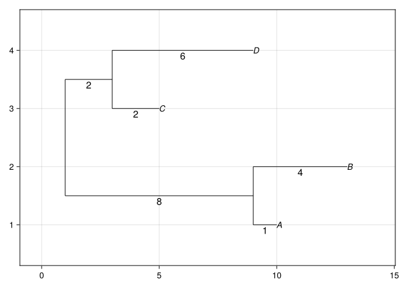

Figure 5: The same phylogeny with edge-length labels shown.

### 5.3 Updating several attributes together

A single call to `update!` can change several related attributes. Here we hide the edge lengths, show the internal-node names and edge numbers, recolor the edges and edge numbers, and increase the label font size:

```julia
update!(
    plot_result.plot;
    showedgelength = false,
    shownodelabel = true,
    showedgenumber = true,
    edgecolor = "steelblue4",
    edgenumbercolor = "darkorange",
    leaffontsize = 24,
)
```

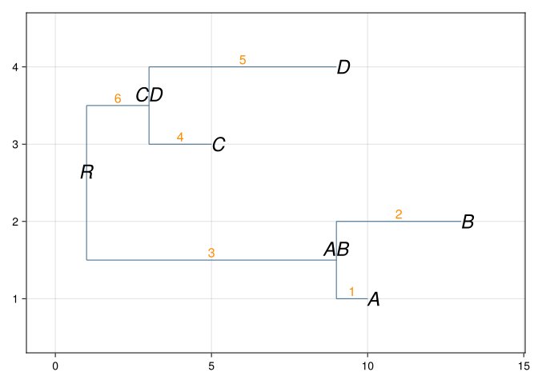

Figure 6: Several plot attributes changed in one `update!` call.

### 5.4 Updatable `PhylogenyPlot` attributes

Every attribute declared by `PhylogenyPlot` can be supplied to `plot` or changed later with `update!`. In the table, a *Makie color* can be a named color such as `:steelblue` or `"steelblue"`, a `Colorant`, or a `(color, alpha)` tuple.

| Keyword | Accepted values | Description |
| --- | --- | --- |
| `clip_planes` | `Makie.automatic`, a `Makie.Plane3f`, or a vector of planes | Inherit or set clipping planes for the rendered marks. |
| `useedgelength` | `Bool` | Use stored edge lengths for horizontal edge extensions. |
| `showleaflabel` | `Bool` | Show or hide leaf names. |
| `shownodelabel` | `Bool` | Show or hide internal-node names. |
| `shownodenumber` | `Bool` | Show or hide node numbers. |
| `showedgelength` | `Bool` | Show or hide edge-length labels. |
| `showedgenumber` | `Bool` | Show or hide edge numbers. |
| `showgamma` | `Bool` | Show or hide hybrid-edge inheritance probabilities. |
| `edgecolor` | Makie color or `AbstractDict` keyed by edge number | Set one edge color or set colors for individual edges. |
| `defaultedgecolor` | Makie color or `nothing` | Set the fallback color for edges absent from an `edgecolor` dictionary. |
| `majorhybridedgecolor` | `AbstractString` color name | Set the color of major hybrid edges. |
| `minorhybridedgecolor` | `AbstractString` color name | Set the color of minor hybrid edges. |
| `edgewidth` | `Number` or `AbstractDict` with numeric values | Set one edge width or set widths for individual edge numbers. |
| `minorlinetype` | `nothing`, `Symbol`, `AbstractString`, or integer code | Set the minor hybrid-edge line style; `"blank"` or `0` hides it. |
| `arrowlen` | `nothing` or `Real` | Set the minor hybrid-edge arrow length. |
| `nodelabel` | `AbstractDataFrame` | Supply custom node labels; the first two columns contain node numbers and labels. |
| `edgelabel` | `AbstractDataFrame` | Supply custom edge labels; the first two columns contain edge numbers and labels. |
| `nodeimages` | `nothing`, `AbstractDict`, or callable | Map node selectors or node objects to image annotations. |
| `edgeimages` | `nothing`, `AbstractDict`, or callable | Map edge selectors or edge objects to image annotations. |
| `nodefontsize` | `Real` or a nonempty vector or tuple of real values | Set custom node-label font sizes. |
| `edgefontsize` | `Real` or a nonempty vector or tuple of real values | Set custom edge-label font sizes. |
| `nodelabelcolor` | Makie color | Set the custom node-label color. |
| `edgelabelcolor` | Makie color | Set the custom edge-label color. |
| `edgenumbercolor` | Makie color | Set the edge-number color. |
| `nodelabeladj` | `Real` or a two-element vector or tuple of real values | Set custom node-label alignment. |
| `edgelabeladj` | `Real` or a two-element vector or tuple of real values | Set custom edge-label alignment. |
| `leafoffset` | `Real` | Move leaf names horizontally away from their leaf positions. |
| `leaffontsize` | `Real` or a nonempty vector or tuple of real values | Set leaf-name and internal-node-name font sizes. |
| `xlim` | `nothing` or a two-element numeric vector or tuple | Set the plot’s x data limits. |
| `ylim` | `nothing` or a two-element numeric vector or tuple | Set the plot’s y data limits. |
| `style` | `:fulltree` or `:majortree` | Select the full-tree or major-tree layout. |

### 5.5 Updating the axis

The axis is separate from the `PhylogenyPlot`, so its attributes are changed through `plot_result.axis`. The following assignments add a title and x-axis ticks, show the vertical grid, hide the horizontal grid, and remove the top and right spines:

```julia
plot_result.axis.title = "Edge-length-scaled phylogeny"
plot_result.axis.xticks = 0:2:12
plot_result.axis.xgridvisible = true
plot_result.axis.ygridvisible = false
plot_result.axis.topspinevisible = false
plot_result.axis.rightspinevisible = false
```

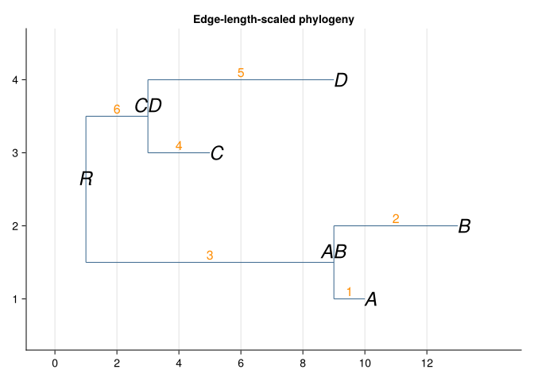

Figure 7: Axis attributes changed without reconstructing the phylogeny plot.

## 6 Compose using an existing Makie axis

When composing complex figures with Makie, we can build a figure in layers by creating the `Figure` and `Axis` ourselves. We pass the axis as the first argument to `plot!` and the phylogeny as the second. The `plot!` function adds the phylogeny to the existing axis and returns the new `PhylogenyPlot` directly.

```julia
composed_figure = Figure(size = (900, 460))

composed_axis = Axis(
    composed_figure[1, 1];
    title = "A composed phylogeny figure",
)

composed_tree_plot = plot!(
    composed_axis,
    phylogeny;
    useedgelength = true,
    leafoffset = 0.2,
    xlim = (-1, 13),
)
```

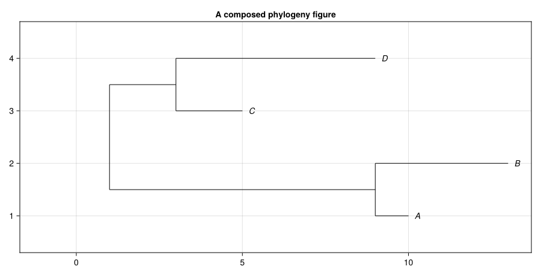

Figure 8: A phylogeny drawn into an explicitly constructed Makie axis.

The figure and axis remain available for additional panels, labels, legends, and annotations.

## 7 Practice

Create a composed figure for this phylogeny:

```
((A:1,B:1)AB:2,(C:1,D:1)CD:2)root;
```

Required steps:

1. Construct the phylogeny object.
2. Create a `Figure` and `Axis`.
3. Draw the phylogeny with `plot!` and `useedgelength = true`.
4. Display internal-node labels.
5. Query and inspect the leaf-position table.
6. Add the text `"root"` at the calculated root position.

Back to top